# DS202_Team

HanSun, XinyiZhu

2020.2.10

### What did you do in lab1 and how this time is different

We learned to push and pull the documents through the Git. In lab2 we also did the data exploration on chocolate rating.

### Question set(team)

#### 1. What is the overall number of chocolate rated?

```r
str(choco)
```

```
## 'data.frame':    1852 obs. of  9 variables:
##  $ Company             : Factor w/ 431 levels "A. Morin","Acalli",..: 1 1 1 1 1 1 1 1 1 1 ...
##  $ Specific.Bean.Origin: Factor w/ 1067 levels "\"heirloom\", Arriba Nacional",..: 15 504 752 578 138 366 251 119 760 217 ...
##  $ REF                 : int  1876 1676 1011 1011 1011 1011 1015 1015 1015 1015 ...
##  $ Review.Date         : int  2016 2015 2013 2013 2013 2013 2013 2013 2013 2013 ...
##  $ Cocoa.Pct           : num  63 70 70 70 70 70 70 70 70 70 ...
##  $ Company.Location    : Factor w/ 61 levels "Amsterdam","Argentina",..: 19 19 19 19 19 19 19 19 19 19 ...
##  $ Rating              : num  3.75 2.75 2.75 3 3.25 3.75 2.75 3 3.25 4 ...
##  $ Bean.Type           : Factor w/ 41 levels "","Amazon","Amazon mix",..: 1 1 1 9 1 1 1 1 1 34 ...
##  $ Broad.Bean.Origin   : Factor w/ 100 levels "","Africa, Carribean, C. Am.",..: 69 79 54 47 6 23 12 7 55 92 ...
```

```r
library(plyr)
count(choco$Rating)
```

```
##       x freq
## 1  1.00    4
## 2  1.50   10
## 3  1.75    3
## 4  2.00   32
## 5  2.25   14
## 6  2.50  128
## 7  2.75  265
## 8  3.00  349
## 9  3.25  315
## 10 3.50  407
## 11 3.75  224
## 12 4.00   99
## 13 5.00    2
```

The total number of chocolate rated is 1852.

#### 2. How does the number of ratings depend on the year? Draw a bar chart of the number of reports.

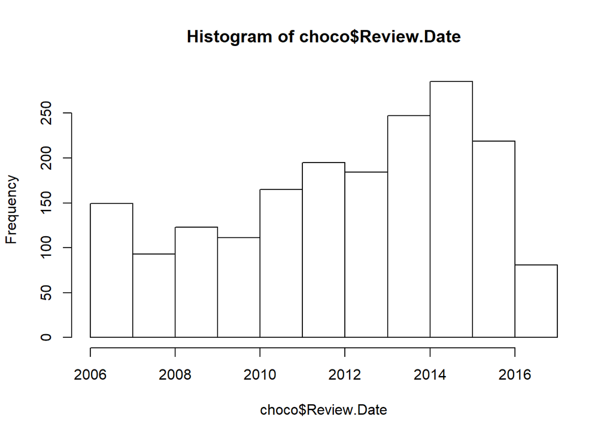

```r
hist(choco$Review.Date)
```

#### 3. Which are the three locations with the most ratings? How do ratings compare across these company locations?

```r
table <- sort.int(table(choco$Company.Location), decreasing = TRUE)
table[1:3]
```

```
##
## U.S.A. France Canada
##    787    158    132
```

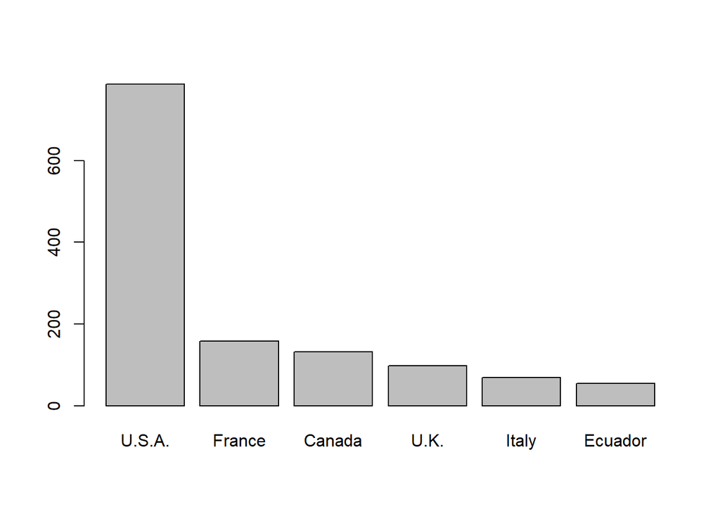

```r
barplot(head(table))
```

The top 3 locations are USA, France, and Canada. USA’s rating is dramatically larger than other 2 company locations, and France’s rating is a little bit larger than Canada’s rating but they are almost similar.

#### 4. Brainstorm and write down an interesting question that can be answer from the dataset. The question should not duplicate the questions above.

In 2015, which company has the lowest rating?

#### 5.Answer the question from the dataset.

```r
## In 2015, which company has the lowest rating?
date2015<- choco[choco$Review.Date == 2015, ]
date2015[which.min(date2015$Rating), ]
```

```
##       Company Specific.Bean.Origin  REF Review.Date Cocoa.Pct
## 1011 Love Bar            Nicaragua 1502        2015        75
##      Company.Location Rating Bean.Type Broad.Bean.Origin
## 1011           U.S.A.      2                   Nicaragua
```

Therefore, 1011 Love Bar has the lowest rating in 2015.

#### 6. Write one paragraph commenting on the workflow.

In this Lab work, we collaborate with our teammates to practice “push and pull files” through github in terminal and R fundamentals and basic graphics, such as finding a min value and a bar plot. And, we learnt how to create an interesting question by ourselves based on the dataset and solved it.